# Data Analysis example

[output not shown]

## Josh Chapman

The Australian Institute of Sport data contains variables on height, weight, and other body measurements for elite male and female athletes training at the facility.

Objectives:

### Executive Summary

My model seems like a very good predictor of body fat percentage. From the marginal model plot it is almost a perfect fit with the data. It does veer off at some points, but thats at points where there is not a lot of data so the variance is higher. The residual plots are evenly distributed around 0 with no clear pattern.

Tukey test Hypotheses: NH: δ = 0 versus AH: δ != 0. Corresponds to NH of no curvature of mean function versus AH that there is curvature. test statistic is 0.416 p-value = .677 Conclusion failure to reject the NH, there is not enough evidence to say that the mean function is curved.

NH: there is no difference in fat percentage between typically sized male and female basketball players AH: There is a difference in fat percentage between typically sized male and female basketball players upr bound for men is lower than the lwr bound for women so we can reject the NH and say that there is evidence that there is a difference between fat percentage for typically sized male and female basketball players given our data

General Summary of the route I took: I pretty much did everything in order from top down in this document except for the explanation. One thing I did have to go back for was the interpretation of the power transform. I didn’t figure it out until I saw a red flag, which was that RCC behaved opposite for women than for men in my allEffects plot. It really didn’t make sense to me so I reevaluated my model. Then found out that I need to so some more transformations. Doing that fixed the weirdness of RCC and Sex. It was a pain to restructure everything though.

### Initial Data Processing Steps

```r
data(ais)
ais$Sex <- factor(ais$Sex,labels=c("Male","Female"))
summary(ais)
```

```
##      Sex            Ht              Wt              LBM
##  Male  :102   Min.   :148.9   Min.   : 37.80   Min.   : 34.36
##  Female:100   1st Qu.:174.0   1st Qu.: 66.53   1st Qu.: 54.67
##               Median :179.7   Median : 74.40   Median : 63.03
##               Mean   :180.1   Mean   : 75.01   Mean   : 64.87
##               3rd Qu.:186.2   3rd Qu.: 84.12   3rd Qu.: 74.75
##               Max.   :209.4   Max.   :123.20   Max.   :106.00
##
##       RCC             WCC               Hc              Hg
##  Min.   :3.800   Min.   : 3.300   Min.   :35.90   Min.   :11.60
##  1st Qu.:4.372   1st Qu.: 5.900   1st Qu.:40.60   1st Qu.:13.50
##  Median :4.755   Median : 6.850   Median :43.50   Median :14.70
##  Mean   :4.719   Mean   : 7.109   Mean   :43.09   Mean   :14.57
##  3rd Qu.:5.030   3rd Qu.: 8.275   3rd Qu.:45.58   3rd Qu.:15.57
##  Max.   :6.720   Max.   :14.300   Max.   :59.70   Max.   :19.20
##
##       Ferr             BMI             SSF              Bfat
##  Min.   :  8.00   Min.   :16.75   Min.   : 28.00   Min.   : 5.630
##  1st Qu.: 41.25   1st Qu.:21.08   1st Qu.: 43.85   1st Qu.: 8.545
##  Median : 65.50   Median :22.72   Median : 58.60   Median :11.650
##  Mean   : 76.88   Mean   :22.96   Mean   : 69.02   Mean   :13.507
##  3rd Qu.: 97.00   3rd Qu.:24.46   3rd Qu.: 90.35   3rd Qu.:18.080
##  Max.   :234.00   Max.   :34.42   Max.   :200.80   Max.   :35.520
##
##        Label        Sport
##  f-netball:23   row    :37
##  f-row    :22   t_400m :29
##  m-t_400m :18   b_ball :25
##  m-w_polo :17   netball:23
##  m-row    :15   swim   :22
##  f-b_ball :13   field  :19
##  (Other)  :94   (Other):47
```

### Statistical Details

In this section provide details of what you found and justifications for your model-creation decisions and conclusions.

Here are some basic commands to get you started:

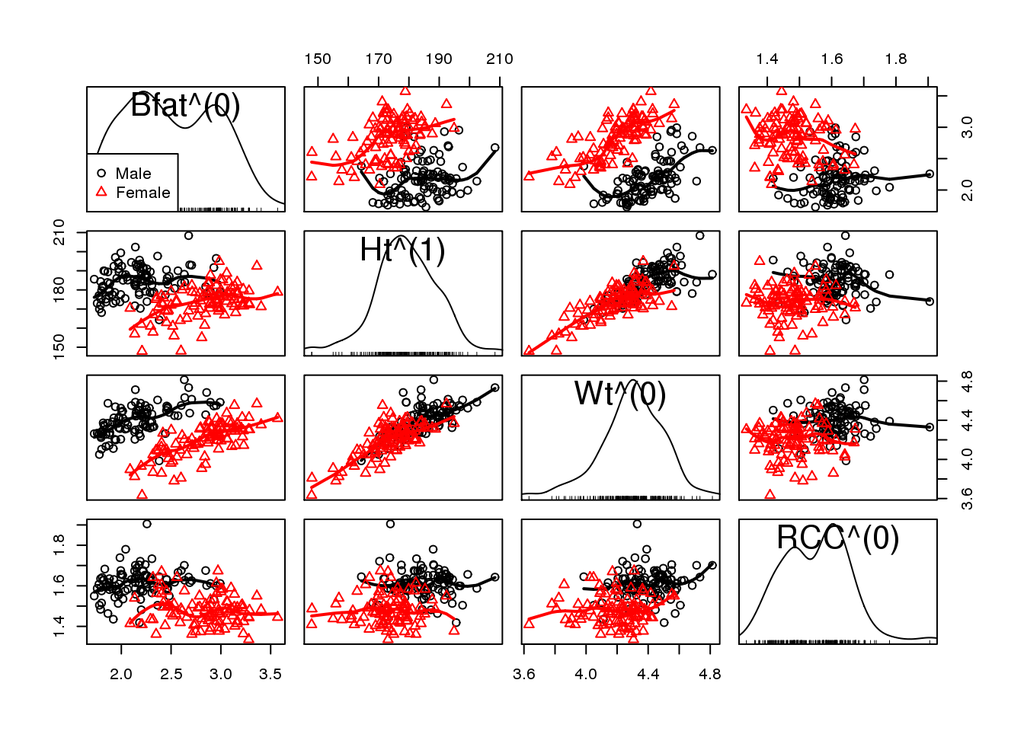

```r
scatterplotMatrix(~Bfat + Ht + Wt + RCC | Sex, smooth=T, by.group=T,reg.line=F, spread=F, data=ais, transform = TRUE)
```

```r
basicmodel <-lm(Bfat ~ Sex + RCC + Wt + Ht, data=ais)
summary(basicmodel)
```

```
##
## Call:
## lm(formula = Bfat ~ Sex + RCC + Wt + Ht, data = ais)
##
## Residuals:
##     Min      1Q  Median      3Q     Max
## -8.6348 -2.2023 -0.4588  1.9668 13.4993
##
## Coefficients:
##             Estimate Std. Error t value Pr(>|t|)
## (Intercept)  9.49832    7.50370   1.266   0.2071
## SexFemale   11.21704    0.74373  15.082   <2e-16 ***
## RCC         -1.10739    0.72194  -1.534   0.1267
## Wt           0.29001    0.02844  10.196   <2e-16 ***
## Ht          -0.10034    0.04117  -2.437   0.0157 *
## ---
## Signif. codes:  0 '***' 0.001 '**' 0.01 '*' 0.05 '.' 0.1 ' ' 1
##
## Residual standard error: 3.411 on 197 degrees of freedom
## Multiple R-squared:  0.7024, Adjusted R-squared:  0.6963
## F-statistic: 116.2 on 4 and 197 DF,  p-value: < 2.2e-16
```

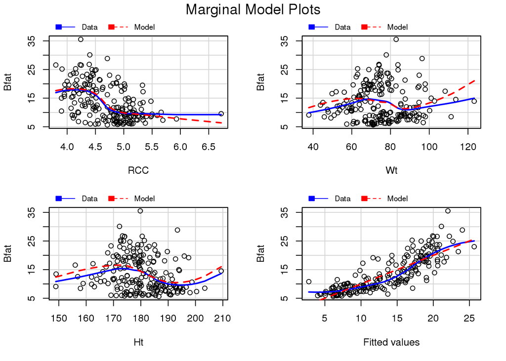

```r
marginalModelPlots(basicmodel)
```

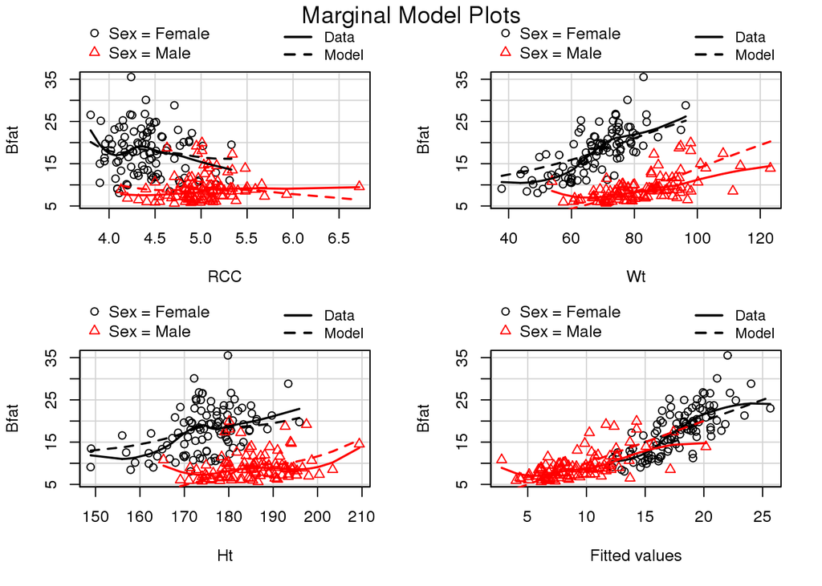

```r
marginalModelPlots(basicmodel, ~ . | Sex)
```

Using the Anova command to see if there are any interactions in the model. There were three interactions that had a p-value less than .05 Sex and RCC, Sex and Ht, RCC and Wt interact. I created a new model based on this evidence.

```r
testmodel <- lm(Bfat ~ (Sex + RCC + Wt + Ht)^2 , data=ais)
Anova(testmodel, data = ais)
```

```
## Anova Table (Type II tests)
##
## Response: Bfat
##            Sum Sq  Df  F value    Pr(>F)
## Sex       2510.76   1 263.7912 < 2.2e-16 ***
## RCC         23.70   1   2.4898 0.1162438
## Wt        1216.07   1 127.7651 < 2.2e-16 ***
## Ht         116.09   1  12.1968 0.0005947 ***
## Sex:RCC     68.46   1   7.1930 0.0079599 **
## Sex:Wt      14.65   1   1.5388 0.2163132
## Sex:Ht      40.96   1   4.3031 0.0393834 *
## RCC:Wt      87.00   1   9.1408 0.0028431 **
## RCC:Ht      36.51   1   3.8358 0.0516255 .
## Wt:Ht       13.72   1   1.4420 0.2313041
## Residuals 1817.93 191
## ---
## Signif. codes:  0 '***' 0.001 '**' 0.01 '*' 0.05 '.' 0.1 ' ' 1
```

```r
basicmodel2 <- lm(Bfat ~ Sex + RCC + Wt + Ht + Sex:RCC + Sex:Ht + RCC:Wt, data=ais)
```

Creating a regression tree to see the most influential predictor variables. From this initial tree it looks like Sex is the most influential predictor followed by Wt then Ht. I then made another tree that was trimmed using the values I got from printcp I thought that .03 looked like a good point to trim. The new tree cut out Ht which suggests that it might not be as important.

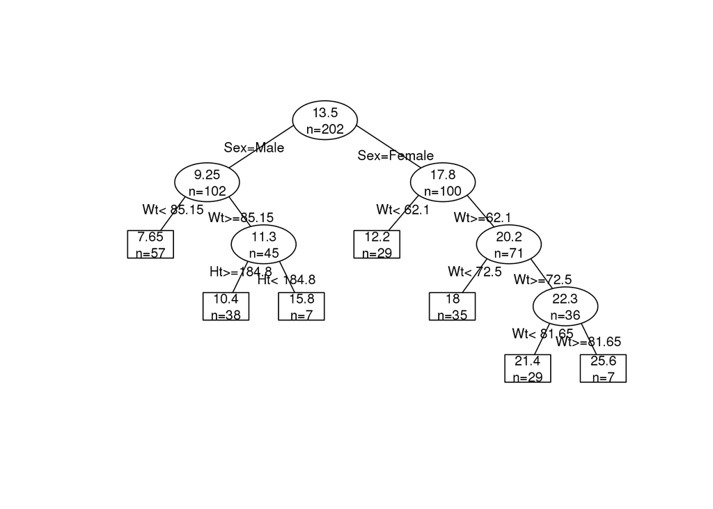

```r
treeobject1<-rpart(Bfat ~ Sex + RCC + Wt + Ht, data=ais)
prettyTree(treeobject1)
```

```r
printcp(treeobject1)
```

```
##
## Regression tree:
## rpart(formula = Bfat ~ Sex + RCC + Wt + Ht, data = ais)
##
## Variables actually used in tree construction:
## [1] Ht  Sex Wt
##
## Root node error: 7701.1/202 = 38.124
##
## n= 202
##
##         CP nsplit rel error  xerror     xstd
## 1 0.484744      0   1.00000 1.01975 0.097365
## 2 0.169567      1   0.51526 0.53202 0.064137
## 3 0.043062      2   0.34569 0.40336 0.053971
## 4 0.041544      3   0.30263 0.40979 0.054063
## 5 0.021934      4   0.26108 0.34349 0.043674
## 6 0.012922      5   0.23915 0.34048 0.042428
## 7 0.010000      6   0.22623 0.32397 0.041763
```

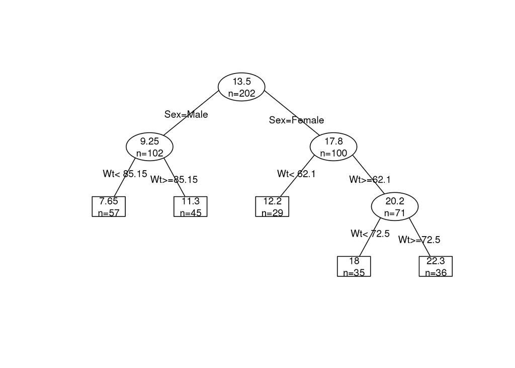

```r
treeobject2 <- prune(treeobject1, c= .03)
prettyTree(treeobject2)
```

Checking to see if transforms on predictors are needed. The power transform output tells me we should log everything except for Ht.

I then did a check to see if a transformation is needed for the response variable using inverseResponsePlot and boxCox. From the boxcox and inverse response plot it looks like doing a log transform on the response would be a good choice so I created a new model based on this. I also did an inverse response plot on the new model but it didn’t suggest that any transformations were needed so I didn’t include it.

```r
summary(a3 <- powerTransform(cbind(Ht, Wt, RCC, Sex, Sex:RCC + Sex:Ht + RCC:Wt)~1, ais))
```

```
## bcPower Transformations to Multinormality
##
##     Est.Power Std.Err. Wald Lower Bound Wald Upper Bound
## Ht     0.4422   0.7770          -1.0807           1.9650
## Wt     0.1030   0.2357          -0.3590           0.5649
## RCC   -0.6764   0.5344          -1.7239           0.3711
## Sex   -0.0857   0.3517          -0.7750           0.6036
##        1.2470   0.1030           1.0452           1.4488
##
## Likelihood ratio tests about transformation parameters
##                                         LRT df         pval
## LR test, lambda = (0 0 0 0 0)    179.561785  5 0.000000e+00
## LR test, lambda = (1 1 1 1 1)     40.145157  5 1.396020e-07
## LR test, lambda = (1 0 0 0 1.25)   2.728422  5 7.417682e-01
```

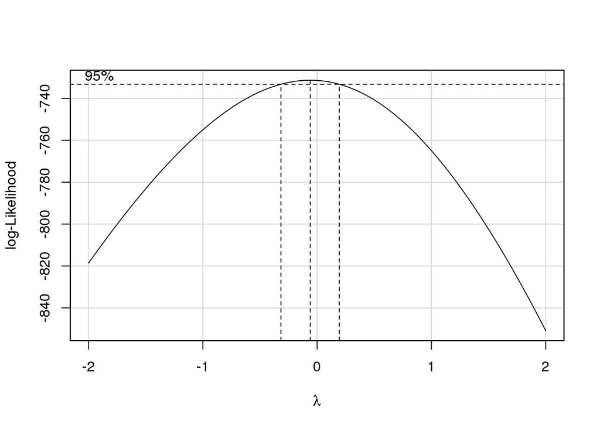

```r
newmodel <-lm(Bfat ~ Sex + log(RCC) + log(Wt) + Ht + Sex:log(RCC) + Sex:Ht + log(RCC):log(Wt), data=ais)
boxCox(newmodel)
```

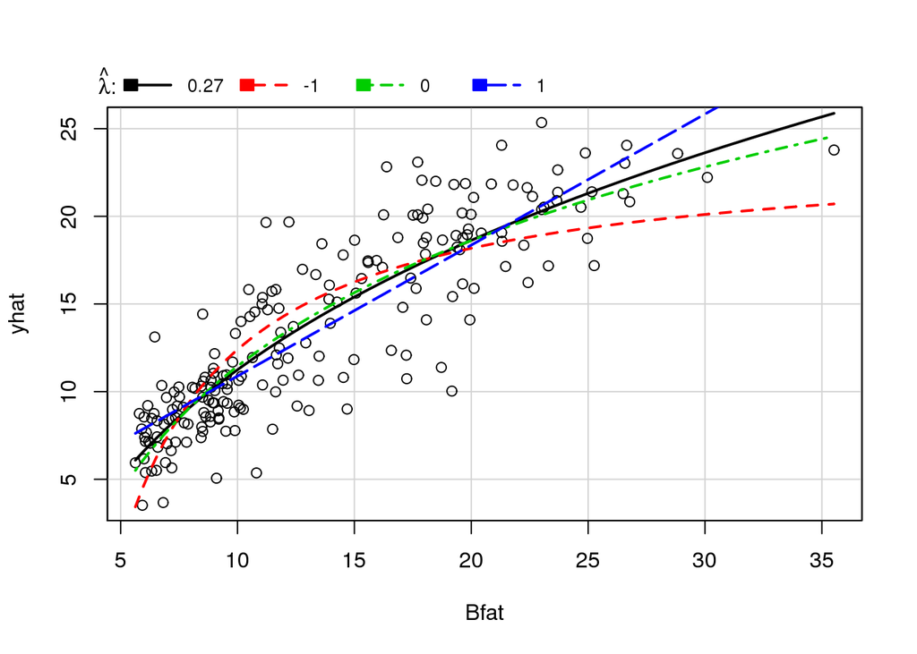

```
##       lambda      RSS
## 1  0.2683658 1338.343
## 2 -1.0000000 1651.687
## 3  0.0000000 1353.724
## 4  1.0000000 1454.429
```

```r
inverseResponsePlot(newmodel)
```

```r
logmodel <- lm(log(Bfat) ~ Sex + log(RCC) + log(Wt) + Ht + Sex:log(RCC) + Sex:Ht + RCC:log(Wt), data=ais)
summary(logmodel)
```

```
##
## Call:
## lm(formula = log(Bfat) ~ Sex + log(RCC) + log(Wt) + Ht + Sex:log(RCC) +
##     Sex:Ht + RCC:log(Wt), data = ais)
##
## Residuals:
##      Min       1Q   Median       3Q      Max
## -0.55187 -0.17526 -0.00398  0.13149  0.68130
##
## Coefficients:
##                      Estimate Std. Error t value Pr(>|t|)
## (Intercept)        -12.391230   5.166275  -2.398 0.017410 *
## SexFemale            2.924094   1.420823   2.058 0.040924 *
## log(RCC)             6.210420   3.277574   1.895 0.059603 .
## log(Wt)              2.886018   0.698987   4.129 5.41e-05 ***
## Ht                  -0.012335   0.003360  -3.671 0.000313 ***
## SexFemale:log(RCC)  -1.847823   0.694003  -2.663 0.008406 **
## SexFemale:Ht         0.004486   0.003991   1.124 0.262432
## log(Wt):RCC         -0.264888   0.145452  -1.821 0.070127 .
## ---
## Signif. codes:  0 '***' 0.001 '**' 0.01 '*' 0.05 '.' 0.1 ' ' 1
##
## Residual standard error: 0.219 on 194 degrees of freedom
## Multiple R-squared:  0.7736, Adjusted R-squared:  0.7655
## F-statistic: 94.71 on 7 and 194 DF,  p-value: < 2.2e-16
```

Checking to see if there are any outliers, or major influences. From the results of the Bonferroni test it doesn’t look like there is any proof of outliers. I also tried dfbetas but decided not to include it because I have already shown the bonferroni analysis I don’t see any evidence of outliers or major influences.

```r
outlierTest(logmodel)
```

```
##
## No Studentized residuals with Bonferonni p < 0.05
## Largest |rstudent|:
##     rstudent unadjusted p-value Bonferonni p
## 184 3.240413          0.0014057      0.28396
```

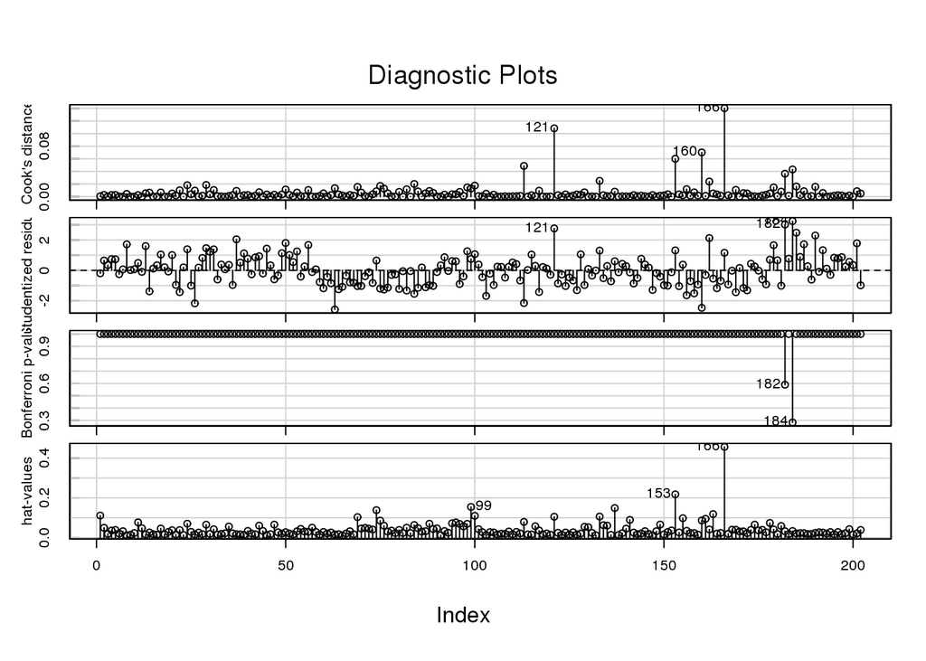

```r
influenceIndexPlot(logmodel, id.n=3)
```

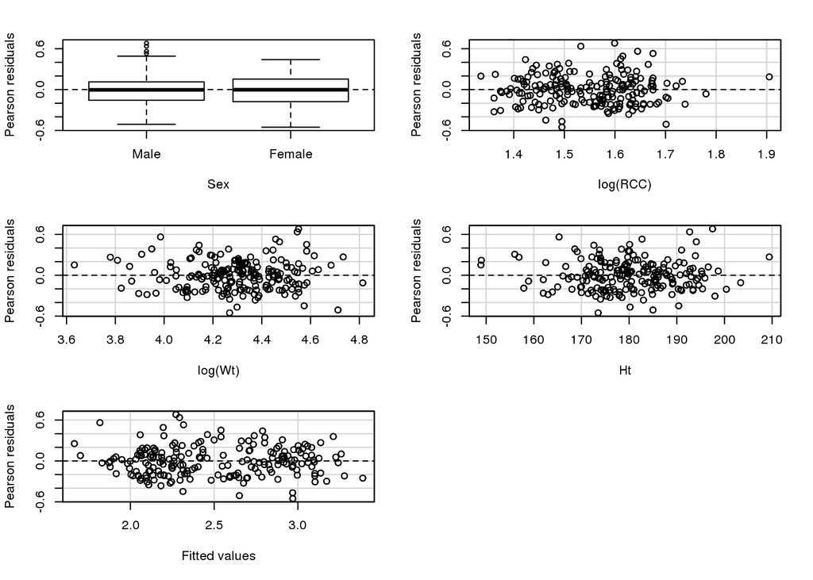

```
##            Test stat Pr(>|t|)
## Sex               NA       NA
## log(RCC)       0.407    0.685
## log(Wt)        1.529    0.128
## Ht             2.266    0.025
## Tukey test    -0.074    0.941
```

```r
residualPlots(logmodel, quadratic=FALSE)
```

```r
ncvTest(logmodel)
```

```
## Non-constant Variance Score Test
## Variance formula: ~ fitted.values
## Chisquare = 0.1996406    Df = 1     p = 0.6550111
```

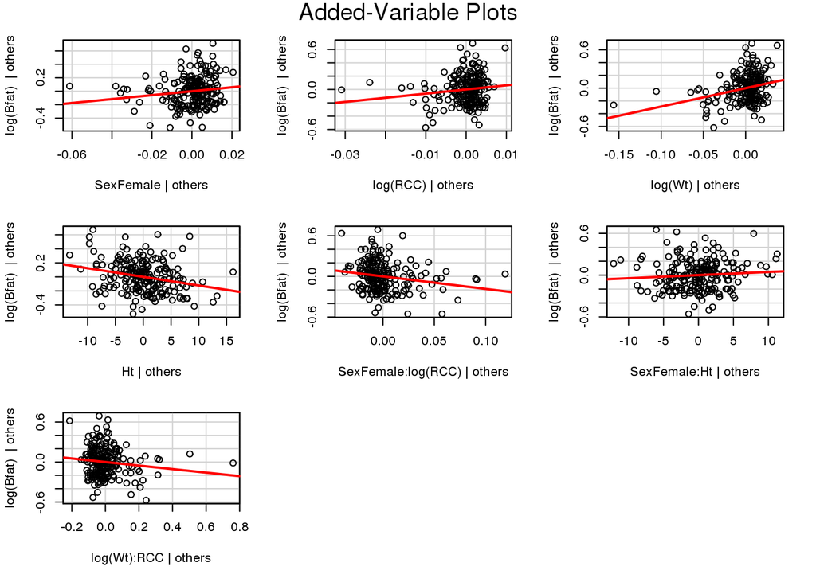

```r
avPlots(logmodel)
```

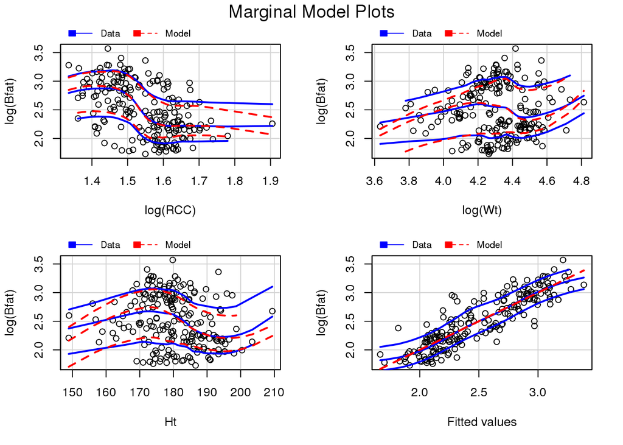

```r
marginalModelPlots(logmodel, sd=TRUE)
```

Checking to see if I can simplify my model anymore, backward elimination suggests that I remove the interaction between Sex and Ht. So I did and created a new model.

```r
ansf2 = step(logmodel, scope=list(lower= ~ Sex+log(RCC)+log(Wt)+Ht, upper= ~ Sex + log(RCC) + log(Wt) + Ht + Sex:log(RCC) + Sex:Ht + RCC:log(Wt)), direction="backward", data = ais, scale=sigmaHat(logmodel)^2)
```

```
## Start:  AIC=8
## log(Bfat) ~ Sex + log(RCC) + log(Wt) + Ht + Sex:log(RCC) + Sex:Ht +
##     RCC:log(Wt)
##
##                Df Sum of Sq    RSS      Cp
## - Sex:Ht        1   0.06059 9.3664  7.2632
## <none>                      9.3058  8.0000
## - log(Wt):RCC   1   0.15909 9.4649  9.3165
## - Sex:log(RCC)  1   0.34006 9.6459 13.0892
##
## Step:  AIC=7.26
## log(Bfat) ~ Sex + log(RCC) + log(Wt) + Ht + Sex:log(RCC) + log(Wt):RCC
##
##                Df Sum of Sq    RSS      Cp
## <none>                      9.3664  7.2632
## - log(Wt):RCC   1   0.22981 9.5962 10.0540
## - Sex:log(RCC)  1   0.42531 9.7917 14.1297
```

```r
logmodel2 <- lm(log(Bfat) ~ Sex + log(RCC) + log(Wt) + Ht + Sex:log(RCC) + RCC:log(Wt), data=ais)
summary(logmodel2)
```

```
##
## Call:
## lm(formula = log(Bfat) ~ Sex + log(RCC) + log(Wt) + Ht + Sex:log(RCC) +
##     RCC:log(Wt), data = ais)
##
## Residuals:
##      Min       1Q   Median       3Q      Max
## -0.55817 -0.18497  0.00449  0.13555  0.65421
##
## Coefficients:
##                      Estimate Std. Error t value Pr(>|t|)
## (Intercept)        -14.329705   4.873163  -2.941 0.003673 **
## SexFemale            3.997364   1.052781   3.797 0.000196 ***
## log(RCC)             7.180151   3.164105   2.269 0.024348 *
## log(Wt)              3.096479   0.673892   4.595 7.76e-06 ***
## Ht                  -0.010236   0.002795  -3.662 0.000322 ***
## SexFemale:log(RCC)  -2.017200   0.677900  -2.976 0.003293 **
## log(Wt):RCC         -0.307408   0.140541  -2.187 0.029909 *
## ---
## Signif. codes:  0 '***' 0.001 '**' 0.01 '*' 0.05 '.' 0.1 ' ' 1
##
## Residual standard error: 0.2192 on 195 degrees of freedom
## Multiple R-squared:  0.7721, Adjusted R-squared:  0.7651
## F-statistic: 110.1 on 6 and 195 DF,  p-value: < 2.2e-16
```

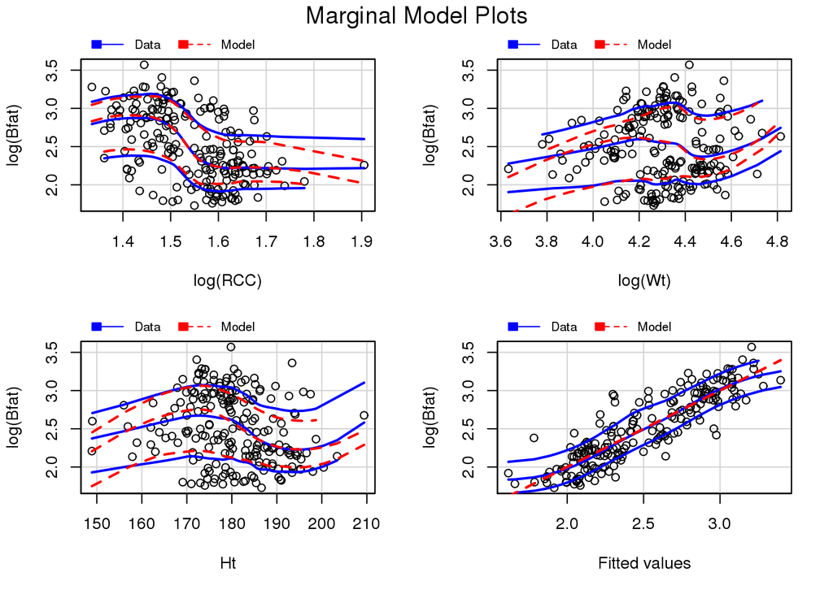

```r
marginalModelPlots(logmodel2, sd=TRUE)
```

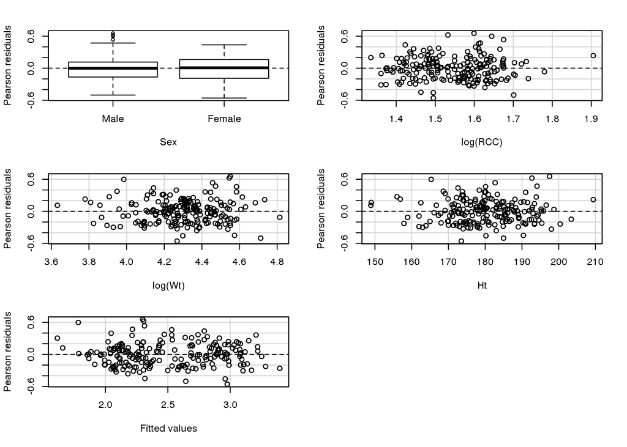

```
##            Test stat Pr(>|t|)
## Sex               NA       NA
## log(RCC)       0.881    0.379
## log(Wt)        0.712    0.477
## Ht             0.762    0.447
## Tukey test     0.416    0.677
```

```r
residualPlots(logmodel2, quadratic=FALSE)
```

Model examination:

[figure not shown]

```r
plot(allEffects(logmodel2, default.levels=50), ask=FALSE)
```

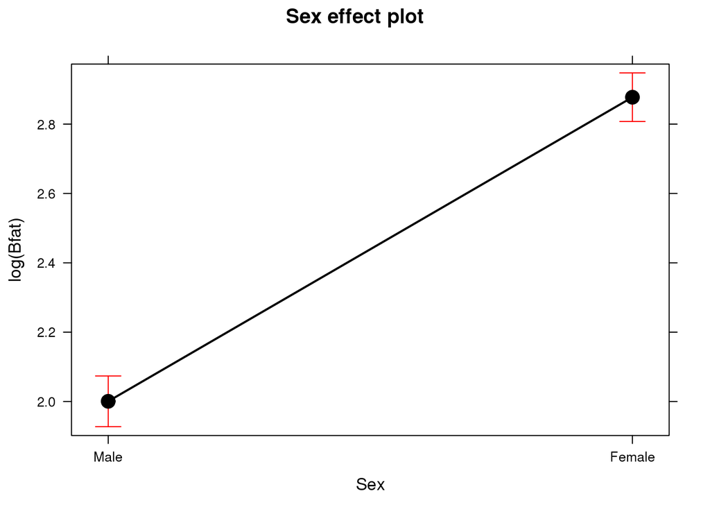

```r
plot(Effect(c("Sex"), logmodel2))
```

```r
logmodel2.lsm <- lsmeans(logmodel2, "Sex")
```

```
## NOTE: Results may be misleading due to involvement in interactions
```

```r
contrast(logmodel2.lsm, list(c1 = c(-1, 1)))
```

```
##  contrast estimate         SE  df t.ratio p.value
##  c1       0.867648 0.04802411 195  18.067  <.0001
##
## Results are given on the log scale.
```

```r
blogmodel <- lm(log(Bfat) ~ Sex + log(RCC) + log(Wt) + Ht + Sex:log(RCC) + Sex:log(Wt) + log(RCC):log(Wt), data=ais)

predict(blogmodel, data.frame(Sex="Male", RCC=4.7, Ht=201, Wt = 90, Sport = "b_ball"), interval = "confidence", level=.95)
```

```
##        fit      lwr      upr
## 1 2.166458 2.075576 2.257339
```

```r
predict(blogmodel, data.frame(Sex="Female", RCC=4.7, Ht=180, Wt = 70, Sport = "b_ball"), interval = "confidence", level=.95)
```

```
##        fit     lwr      upr
## 1 2.819002 2.75313 2.884874
```

bais <- ais[which(ais$Sport==‘b_ball’), ]

blogmodel2 <- lm(log(Bfat) ~ Sex + log(RCC) + log(Wt) + Ht + Sex:log(RCC) + Sex:log(Wt) + log(RCC):log(Wt), data=bais)